# Exploring the BRFSS data

## Setup

### Load packages

```r
library(ggplot2)
library(dplyr)
```

### Load data

```r
load("brfss2013.RData")
```

## Part 1: Data

A study conclusion is generalizable to population only if the study uses random sampling. In order to conduct the BRFSS(Behavioral Risk Factor Surveillance System), states obtain samples of telephone numbers from CDC(Centers for Disease Control and Prevention). Random Digit Dialing (RDD) techniques is used to obtain landlines and cell phone numbers. BRFSS uses random sampling to collect data so survey conclusions are generalizable.

BRFSS is an observational study and does not uses random assignments so study results can not be used to draw causal conclusions.

## Part 2: Research questions

**Research quesion 1:** How sleep duration is related with general health?

**Research quesion 2:** How cholesterol is related with heart disease?

**Research quesion 3:** How mental health is related with gender?

## Part 3: Exploratory data analysis

**Research quesion 1:** For our research question 1 we are interested in two fields of the dataset. One is *genhlth* which represents General Health and *sleptim1* which is On average, how many hours of sleep do one get in a 24-hour period. Lets find out unique values of these two fields.

```r
unique(brfss2013$genhlth)
```

```
## [1] Fair      Good      Very good Excellent Poor      <NA>
## Levels: Excellent Very good Good Fair Poor
```

```r
unique(brfss2013$sleptim1)
```

```
##  [1]  NA   6   9   8   7   3   5  10   4   2  12  16  11  13  14  19  18
## [18]  15   1  20  17  24  23  21  22 103 450   0
```

*genhlth* field has some missing values which is represented by NA and *sleptim1* has some extreme values like 1,2,19,20 etc and also has some invalid entry like 103,450. We want to filter dataset so that there are no missing values. We also discard records where sleep time is greater than 21 or less than 1 as these values are either extremely rare or invalid. We take a sample of size 10000 from filtered dataset.

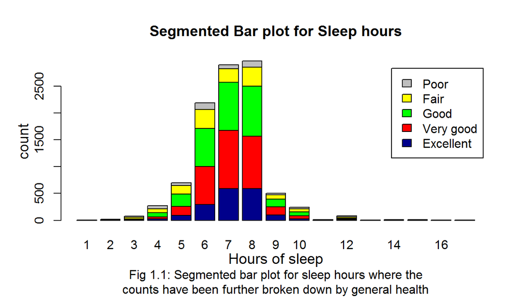

```r
#Filter dataset
filtered_data<-brfss2013[,c("genhlth","sleptim1")]%>%filter(sleptim1>0&sleptim1<22&is.na(genhlth)==FALSE)

sample_data<-sample_n(filtered_data,10000,replace = FALSE)

counts <- table(sample_data$genhlth, sample_data$sleptim1)


barplot(counts, main="Segmented Bar plot for Sleep hours", sub="Fig 1.1: Segmented bar plot for sleep hours where the
counts have been further broken down by general health",
   col=c("darkblue","red","green","yellow","grey"),
    legend = rownames(counts))

title(ylab="count", line=2, cex.lab=1.2)
title(xlab="Hours of sleep", line=2, cex.lab=1.2 )
```

From Fig 1.1 distribiution of sleep duration looks like a normal curve. So we can expect mean and median of sleep hours to be very close. Let’s take a look at summary statistics of sleep duration.

```r
sample_data%>%summarise(mean_st = mean(sleptim1), sd_st = sd(sleptim1), iqr_st= IQR(sleptim1), median_st=median(sleptim1), n = n())
```

```
##   mean_st    sd_st iqr_st median_st     n
## 1  7.0556 1.436215      2         7 10000
```

Close value of mean and median support our assumption. From summary statistics we see standard deviation is around 1.44 and mean is nearly 7.06 so from 68-95-99 rule 68% people sleeps around from 8.5 to 5.62 hours.

Standarized bar plot of figure 1.1 would help us to understand relationship between sleep hour and general health.

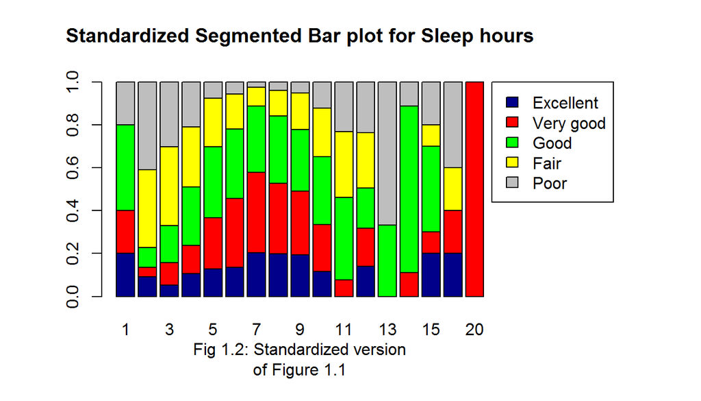

```r
plot.new()

prop = prop.table(counts,margin=2)

par(oma=c(0,1,0,8),xpd=NA)
barplot(prop, col=c("darkblue","red","green","yellow","grey"))

title(main="Standardized Segmented Bar plot for Sleep hours", line=2, cex.lab=1.2 )
title(sub="Fig 1.2: Standardized version
of Figure 1.1", line=3, cex.lab=1.2 )
par(oma=c(0,0,0,7),xpd=NA)

legend(20,1,legend=rownames(counts),fill=c("darkblue","red","green","yellow","grey"))
```

From figure 1.2 it looks like sleep duration of people with poor health is generally from 1-4 hours. In most cases people who reported to have excellent health sleeps around 6-9 hours. Most people from sleep duration 6 to 9 looks healthy.

**Research quesion 2:** According to medical science high blood cholesterol causes vaious heart diseases. In this research question we want to verify this claim on our dataset. To answer our research question we are interested in two fields of the dataset, one is *cvdcrhd4* which gives us information whether respondent ever diagnosed with angina or coronary heart disease. Another field is *toldhi2* that represents if respondent was diagnosed with high blood cholesterol. Both variables are categorical variables. Let’s take a look at the unique values of theses variables.

```r
unique(brfss2013$cvdcrhd4)
```

```
## [1] <NA> No   Yes
## Levels: Yes No
```

```r
unique(brfss2013$toldhi2)
```

```
## [1] Yes  No   <NA>
## Levels: Yes No
```

We only take into consideration the records where both high blood cholestorol and heart disease column is not NA. Our sample size will be 10000.

```r
filtered_data<-brfss2013[,c("cvdcrhd4","toldhi2")]%>%filter(is.na(cvdcrhd4)==FALSE&is.na(toldhi2)==FALSE)

sample_data<-sample_n(filtered_data,10000,replace = FALSE)
```

Standarized segmented barplot would help us to answer the research question.

[figure not shown]

```r
counts <- table(sample_data$toldhi2, sample_data$cvdcrhd4,dnn=c("High blood pressure","Diagnosed with heart disease"))
#View(counts)
prop = prop.table(counts,margin=2)

par(xpd=NA,oma=c(0,1,0,8))
barplot(prop, main="Standarized Segmented Bar plot of high
blood cholesterol", sub="Fig 2.1: Segmented bar plot for high
blood cholesterol where counts are broken down by general health",col=c("red","green")
   )

legend(2.5,1,fill=c("red","green"),
    legend = c("Heart disease","No heart disease"))

title(xlab="High Blood Cholesterol", line=2, cex.lab=1 )
```

```r
prop
```

```
##                    Diagnosed with heart disease
## High blood pressure       Yes        No
##                 Yes 0.7111437 0.4108178
##                 No  0.2888563 0.5891822
```

**Research quesion 3:**

It is often said that female are more emotional than male. In our research question 3 we would like to investigate how mental health of respondants in last 30 days differ from male to female. For this researh question we are interested in two fields of brfss2013 dataset. One is *sex* which represents gender of the respondant and another is *menthlth* which represents number of days mental health not good during the past 30 days. Let’s check unique values of these two fields.

```r
unique(brfss2013$sex)
```

```
## [1] Female Male   <NA>
## Levels: Male Female
```

```r
unique(brfss2013$menthlth)
```

```
##  [1]   29    0    2   15    1   30    3   NA    5    8    7   10   25    4
## [15]   20   21    6   14   26   18   12   16   28    9   13   17   27   24
## [29]   23   11   22   19 5000  247
```

```r
filtered_data<-brfss2013[,c("sex","menthlth")]%>%filter(is.na(sex)==FALSE&is.na(menthlth)==FALSE)

sample_data<-sample_n(filtered_data,10000,replace = FALSE)
```

Let’s find out the distribiution of number of days mental health was not good in last 30 days.

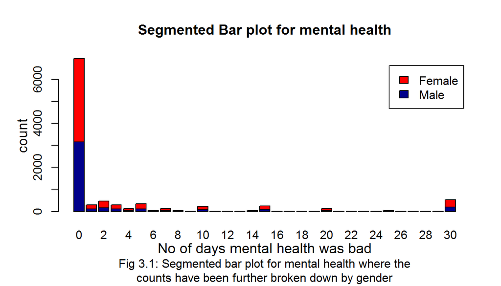

```r
counts <- table(sample_data$sex, sample_data$menthlth)


barplot(counts, main="Segmented Bar plot for mental health", sub="Fig 3.1: Segmented bar plot for mental health where the
counts have been further broken down by gender",
   col=c("darkblue","red"),
    legend = rownames(counts))

title(ylab="count", line=2, cex.lab=1.2)
title(xlab="No of days mental health was bad", line=2, cex.lab=1.2 )
```

Fig 3.1 is a right skewed graph. A standarized bar plot would give us a better understanding of relationship between gender and mental health.

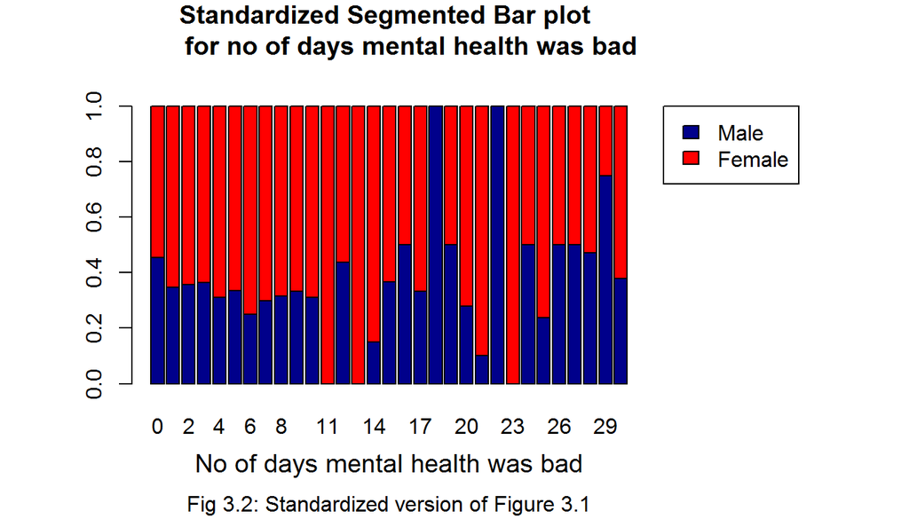

```r
plot.new()

prop = prop.table(counts,margin=2)

par(oma=c(0,1,0,8),xpd=NA)
barplot(prop, col=c("darkblue","red"))

legend(40,1,fill=c("darkblue","red"),
    legend = c("Male","Female"))

title(xlab="No of days mental health was bad", line=2.5, cex.lab=1.2 )

title(main="Standardized Segmented Bar plot
      for no of days mental health was bad", line=2, cex.lab=1.2 )
title(sub="Fig 3.2: Standardized version of Figure 3.1", line=4, cex.lab=1.2 )
```

From figure 3.1 we see that distribiution is right skewed and most of sample come from day range [0 - 8] . From figure 3.2 we see that in day range [0 - 8] proportion of female repondants are higher than male respondants. Let’s analysise the sample numerically from day range [0-8] as most of the respondants are from this day range according to figure 3.1.

```r
sample_data_0_8<-sample_data%>%filter(menthlth<9)
counts_0_8 <- table(sample_data_0_8$sex, sample_data_0_8$menthlth)
counts_0_8
```

```
##
##             0    1    2    3    4    5    6    7    8
##   Male   3157  105  168  110   39  118   10   37   12
##   Female 3796  197  304  192   87  233   30   87   26
```

```r
prop = prop.table(counts_0_8,margin=2)
prop
```

```
##
##                  0         1         2         3         4         5
##   Male   0.4540486 0.3476821 0.3559322 0.3642384 0.3095238 0.3361823
##   Female 0.5459514 0.6523179 0.6440678 0.6357616 0.6904762 0.6638177
##
##                  6         7         8
##   Male   0.2500000 0.2983871 0.3157895
##   Female 0.7500000 0.7016129 0.6842105
```